# Compare Logistic regression vs. KNN

Panuphan Chaimanee

2024-02-01

## Prepare data

Load data from `churn.csv` then split data into 70% for train and 30% for test.

```r
## Split function
train_test_split <- function(data, size=0.7) {
  set.seed(24)
  n <- nrow(data)
  train_id <- sample(1:n, size*n)
  train_df <- data[train_id, ]
  test_df <- data[-train_id, ]
  return (list(train_df, test_df))
}

## Read data
df <- read_csv("churn.csv")
df
```

| churn | accountlength | internationalplan | voicemailplan | numbervmailmessages | totaldayminutes | totaldaycalls | totaldaycharge | totaleveminutes | totalevecalls | totalevecharge | totalnightminutes | totalnightcalls | totalnightcharge | totalintlminutes | totalintlcalls | totalintlcharge | numbercustomerservicecalls |
| --- | --- | --- | --- | --- | --- | --- | --- | --- | --- | --- | --- | --- | --- | --- | --- | --- | --- |
| No | 128 | no | yes | 25 | 265.1 | 110 | 45.07 | 197.4 | 99 | 16.78 | 244.7 | 91 | 11.01 | 10.0 | 3 | 2.70 | 1 |
| No | 107 | no | yes | 26 | 161.6 | 123 | 27.47 | 195.5 | 103 | 16.62 | 254.4 | 103 | 11.45 | 13.7 | 3 | 3.70 | 1 |
| No | 137 | no | no | 0 | 243.4 | 114 | 41.38 | 121.2 | 110 | 10.30 | 162.6 | 104 | 7.32 | 12.2 | 5 | 3.29 | 0 |
| No | 84 | yes | no | 0 | 299.4 | 71 | 50.90 | 61.9 | 88 | 5.26 | 196.9 | 89 | 8.86 | 6.6 | 7 | 1.78 | 2 |
| No | 75 | yes | no | 0 | 166.7 | 113 | 28.34 | 148.3 | 122 | 12.61 | 186.9 | 121 | 8.41 | 10.1 | 3 | 2.73 | 3 |
| No | 118 | yes | no | 0 | 223.4 | 98 | 37.98 | 220.6 | 101 | 18.75 | 203.9 | 118 | 9.18 | 6.3 | 6 | 1.70 | 0 |
| No | 121 | no | yes | 24 | 218.2 | 88 | 37.09 | 348.5 | 108 | 29.62 | 212.6 | 118 | 9.57 | 7.5 | 7 | 2.03 | 3 |
| No | 147 | yes | no | 0 | 157.0 | 79 | 26.69 | 103.1 | 94 | 8.76 | 211.8 | 96 | 9.53 | 7.1 | 6 | 1.92 | 0 |
| No | 117 | no | no | 0 | 184.5 | 97 | 31.37 | 351.6 | 80 | 29.89 | 215.8 | 90 | 9.71 | 8.7 | 4 | 2.35 | 1 |
| No | 141 | yes | yes | 37 | 258.6 | 84 | 43.96 | 222.0 | 111 | 18.87 | 326.4 | 97 | 14.69 | 11.2 | 5 | 3.02 | 0 |

[output cut: 4990 more lines]

```r
## 1. Split
prep_df <- train_test_split(df)
train_df <- prep_df[[1]] %>%
  select(churn, numbercustomerservicecalls, totaldaycalls, totalevecalls, totalnightcalls, totalintlcalls)
test_df <- prep_df[[2]] %>%
  select(churn, numbercustomerservicecalls, totaldaycalls, totalevecalls, totalnightcalls, totalintlcalls)
```

## Train model

Use `caret` to train logistic regression and knn model. For train glm and knn model will setup `trainControl` to use: - k-fold cross-validation will be used for resampling. - Sets the number of folds for cross-validation to 10. - Repeats the entire cross-validation process 5 times.

```
## [1] "Result of Logistic model:"
```

```
## Generalized Linear Model
##
## 3500 samples
##    5 predictor
##    2 classes: 'No', 'Yes'
##
## No pre-processing
## Resampling: Cross-Validated (10 fold, repeated 5 times)
## Summary of sample sizes: 3151, 3149, 3150, 3151, 3151, 3150, ...
## Resampling results:
##
##   Accuracy   Kappa
##   0.8564016  0.03905652
```

```
## [1] "Result of KNN model:"
```

```
## k-Nearest Neighbors
##
## 3500 samples
##    5 predictor
##    2 classes: 'No', 'Yes'
##
## No pre-processing
## Resampling: Cross-Validated (10 fold, repeated 5 times)
## Summary of sample sizes: 3150, 3150, 3150, 3150, 3150, 3150, ...
## Resampling results across tuning parameters:
##
##   k   Accuracy   Kappa
##    5  0.8416582  -0.015377841
##    7  0.8510873  -0.001205503
##    9  0.8536018  -0.002459709
##   11  0.8540016  -0.002250645
##   13  0.8549167  -0.001007237
##
## Accuracy was used to select the optimal model using the largest value.
## The final value used for the model was k = 13.
```

## Plot ROC

Plot ROC compare between glm and knn:

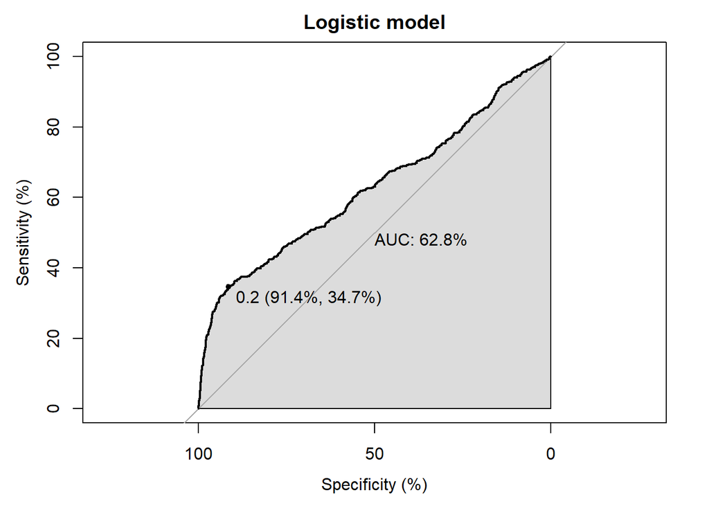

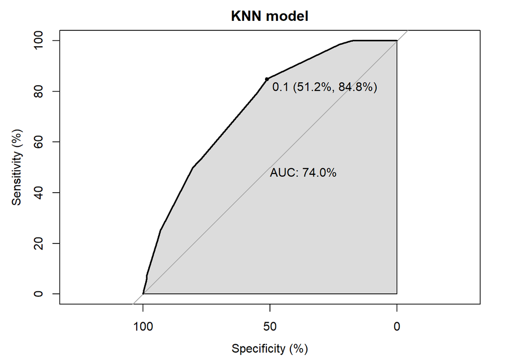

## Evaluate

```
## [1] "Logistic accurary: 0.868"
```

```
## [1] "Logistic confusion matric:"
```

```
## Confusion Matrix and Statistics
##
##           Reference
## Prediction   No  Yes
##        No  1294  194
##        Yes    4    8
##
##                Accuracy : 0.868
##                  95% CI : (0.8498, 0.8847)
##     No Information Rate : 0.8653
##     P-Value [Acc > NIR] : 0.3989
##
##                   Kappa : 0.0606
##
##  Mcnemar's Test P-Value : <2e-16
##
##               Precision : 0.666667
##                  Recall : 0.039604
##                      F1 : 0.074766
##              Prevalence : 0.134667
##          Detection Rate : 0.005333
##    Detection Prevalence : 0.008000
##       Balanced Accuracy : 0.518261
##
##        'Positive' Class : Yes
##
```

```
## [1] "KNN accurary: 0.865333333333333"
```

```
## [1] "KNN confusion matric:"
```

```
## Confusion Matrix and Statistics
##
##           Reference
## Prediction   No  Yes
##        No  1298  202
##        Yes    0    0
##
##                Accuracy : 0.8653
##                  95% CI : (0.847, 0.8822)
##     No Information Rate : 0.8653
##     P-Value [Acc > NIR] : 0.5188
##
##                   Kappa : 0
##
##  Mcnemar's Test P-Value : <2e-16
##
##               Precision :     NA
##                  Recall : 0.0000
##                      F1 :     NA
##              Prevalence : 0.1347
##          Detection Rate : 0.0000
##    Detection Prevalence : 0.0000
##       Balanced Accuracy : 0.5000
##
##        'Positive' Class : Yes
##
```

### Confusion Matrices:

- Logistic Regression: Successfully identifies 8 out of 202 “Yes” cases, but misses 194.
- KNN: Fails to identify any “Yes” cases, misclassifying all 202 as “No.”
- This suggests that Logistic Regression has a better ability to detect the minority “Yes” class, albeit with a high number of false negatives.
- Precision: Logistic Regression has a precision of 0.667, meaning that when it predicts “Yes,” it’s correct 66.7% of the time. KNN has undefined precision as it never predicts “Yes.”
- Recall: Logistic Regression has a recall of 0.04, indicating that it only detects 4% of the actual “Yes” cases. KNN has a recall of 0, missing all “Yes” cases.
- F1-Score: Logistic Regression’s F1-score of 0.075 balances precision and recall, but it’s still quite low, suggesting a poor balance between identifying “Yes” cases and avoiding false positives. KNN’s F1-score is undefined.